# Face shape sexual dimorphism population comparison

In this notebook we’ll compare face shape sexual dimorphism between populations (for magnitude and pattern). We will use two complementary approaches: 1. First, we will traverse the dendrogram from fineStructure by testing the sex by population interaction term using a MANOVA. To do that, we will arbitrarily cut the dendrogram at height 6.5 which results in a total of 11 leaves. For each of the 11 leaves we used a MANOVA to test for the sex by population interaction term. If a non-significant term was found, the leaves were merged. Finally, the post-hoc tests for pattern and magnitude were used for those branches with significant differences. We keep track of the initial cluster (11 leaves), and the final cluster (N branches) and export the final dataset.

2. Second, we will compare populations based on their Admixture proportions, with $k = 6$. Specifically, in a first attempt we will generate homogeneous populations that have more than 0.7 assignment proportion for any cluster. In another attempt we will assign individuals to clusters from which they have most of their ancestry proportions assigned to. Finally, we will keep track of both attempt and include them into the final dataset.

## Preliminaries

Load libraries

```r
library(tidyverse)
library(car)
library(dendextend)
library(ape)
source("PhenotypicChangeTests.R")
source("FinestructureLibrary.R") # read in the R functions, which also calls the needed packages
```

Read databases

```r
setwd('..')
path <- getwd()
setwd(paste(path, "/DataBases/Genotypes/Admixture", sep = ""))

#Reading Admixture run
adk6  <- read_delim("geno.6.Q", delim = " ", col_names = FALSE)
adfam <- read_delim("geno.fam", delim = " ", col_names = c("FID", "ID","P","M","Ph")) %>% select(ID)

#Reading covariates
setwd(paste(path, "/DataBases", sep = ""))
covs  <- read_csv("Covariates.csv", col_types = cols(ID = col_character()))

#Reading face PCA
setwd(paste(path, "/DataBases/FacePCA", sep = ""))
scores       <- read_csv("scores.csv", col_names = FALSE)
eigenvectors <- read_csv("eigenvectors.csv", col_names = FALSE)
means        <- read_csv("means.txt", col_names = FALSE)
colnames(scores) <- paste("PC", 1:length(scores), sep="")
face_ids <- read_csv("landmark_ids.txt", col_names = "ID", col_types = cols(ID = col_character()))
face_pca <- cbind(face_ids, scores)

#Reading list of common IDs
setwd(paste(path, "/Results", sep = ""))
common_ids <- read_delim("common_ids.txt", delim = " ", col_names = "ID", col_types = cols(ID = col_character()))

#get only adapt ids
keep  <- which(adfam$ID %in% common_ids$ID)
adk6  <- adk6[keep,]
adfam <- adfam[keep,]

#Subsetting the other databases
tot_samples <- adfam %>% left_join(covs, by = "ID") %>% mutate(BMI = Weight / (Height/100)^2) %>%
  left_join(face_pca, by = "ID") %>% mutate(Sex = as.factor(Sex))
```

Read and plot the fineStructure dendrogram

```r
setwd('..')
path <- getwd()
setwd(paste(path, "/DataBases/Genotypes/FineStructure", sep = ""))

treexml <- xmlTreeParse("total_fs_linked.greedy_outputfile.xml") ## read the tree as xml format
ttree   <- extractTree(treexml) ## extract the tree into ape's phylo format
## Will will instead remove "perfect" node labels
ttree$node.label[ttree$node.label=="1"] <- ""
ttree$node.label[ttree$node.label!=""] <- format(as.numeric(ttree$node.label[ttree$node.label!=""]),digits=2)
tdend <- myapetodend(ttree,factor=1) # convert to dendrogram format

#Get number of IDs per pop
mapstate     <- extractValue(treexml,"Pop") # map state as a finestructure clustering
mapstatelist <- popAsList(mapstate) # .. and as a list of individuals in populations
print('Number of pops is')
```

```
## [1] "Number of pops is"
```

```r
print(length(mapstatelist))
```

```
## [1] 150
```

```r
print('Number of IDs per pop ranges from')
```

```
## [1] "Number of IDs per pop ranges from"
```

```r
summary(unlist(lapply(mapstatelist, function(x) length(x))))
```

```
##    Min. 1st Qu.  Median    Mean 3rd Qu.    Max.
##    1.00    4.00    9.00   25.23   20.00  860.00
```

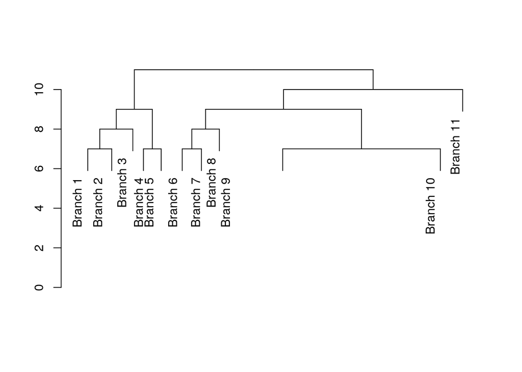

```r
#Cut
tdend_cut <- cut(tdend, h = 6.5)$upper
tdend_cut_low <- cut(tdend, h = 6.5)$lower
tdend_cut %>% hang.dendrogram %>% plot
```

```r
fs_groups <- as.data.frame(matrix(NA, nrow = length(labels(tdend)), ncol = 2))
colnames(fs_groups) <- c("ID", "cluster")
fs_groups$ID <- labels(tdend)
ngroups <- max(as.integer(labels(tdend_cut_low)))

for(i in 1:ngroups){
  fs_groups$cluster[fs_groups$ID %in% labels(tdend_cut_low[[i]])] <- i
}

#get only adapt ids
keep       <- which(fs_groups$ID %in% common_ids$ID)
fs_groups  <- fs_groups[keep,]
#keep order of adfam
fs_groups  <- adfam %>% left_join(fs_groups, by = "ID")
summary(as.factor(fs_groups$cluster))
```

```
##    1    2    3    4    5    6    7    8    9   10   11
##   53  148   25   18   57   93   91   91 1648  216  118
```

```r
#Adding fs_group initial cluster to tot_samples object
tot_samples <- tot_samples %>% left_join(fs_groups, by = "ID")
colnames(tot_samples)[length(tot_samples)] <- c("cluster_initial")
```

We’ll export the truncated dendrogram to newick format for later use

```r
tree_cut <- as.phylo(tdend_cut)
setwd(paste(path, "/Results", sep = ""))
write.tree(phy=tree_cut, file="tree_cut.newick")
```

## Analysis

Traversing the dendrogram. Because 10 independent tests need to be made, we will consider alpha = 0.005

```r
matrix <- tot_samples %>% select(starts_with("PC"))
covs   <- tot_samples %>% select(c("Age", "Height", "BMI","Sex", "cluster_initial"))
covs[,c(1:3)] <- scale(covs[,c(1:3)])

run_Manova <- function(keep){
  fit  <- lm(as.matrix(matrix[keep,]) ~ covs$Age[keep] + covs$Height[keep] + covs$BMI[keep] +
            covs$Sex[keep] * as.factor(covs$cluster_initial[keep]))
  Manova(fit, type = 3, test.statistic = "Wilks")
}

#Getting model matrix, and runnning vector change
keep <- covs$cluster_initial == 1 | covs$cluster_initial == 2
run_Manova(keep)
```

```
##
## Type III MANOVA Tests: Wilks test statistic
##                                                      Df test stat approx F
## (Intercept)                                           1   0.24574   42.972
## covs$Age[keep]                                        1   0.59808    9.408
## covs$Height[keep]                                     1   0.90307    1.503
## covs$BMI[keep]                                        1   0.56150   10.933
## covs$Sex[keep]                                        1   0.56931   10.591
## as.factor(covs$cluster_initial[keep])                 1   0.63617    8.007
## covs$Sex[keep]:as.factor(covs$cluster_initial[keep])  1   0.93207    1.020
##                                                      num Df den Df
## (Intercept)                                              13    182
## covs$Age[keep]                                           13    182
## covs$Height[keep]                                        13    182
## covs$BMI[keep]                                           13    182
## covs$Sex[keep]                                           13    182
## as.factor(covs$cluster_initial[keep])                    13    182
## covs$Sex[keep]:as.factor(covs$cluster_initial[keep])     13    182
##                                                         Pr(>F)
## (Intercept)                                          < 2.2e-16 ***
## covs$Age[keep]                                       8.840e-15 ***
## covs$Height[keep]                                       0.1198
## covs$BMI[keep]                                       < 2.2e-16 ***
## covs$Sex[keep]                                       < 2.2e-16 ***
## as.factor(covs$cluster_initial[keep])                1.433e-12 ***
## covs$Sex[keep]:as.factor(covs$cluster_initial[keep])    0.4336
## ---
## Signif. codes:  0 '***' 0.001 '**' 0.01 '*' 0.05 '.' 0.1 ' ' 1
```

```r
#Changing value of branch 2 to 1
covs$cluster_initial[covs$cluster_initial == 2] <- 1

#Branch1vs3
keep <- covs$cluster_initial == 1 | covs$cluster_initial == 3
run_Manova(keep)
```

```
##
## Type III MANOVA Tests: Wilks test statistic
##                                                      Df test stat approx F
## (Intercept)                                           1   0.13931   98.380
## covs$Age[keep]                                        1   0.61978    9.768
## covs$Height[keep]                                     1   0.88537    2.062
## covs$BMI[keep]                                        1   0.56886   12.068
## covs$Sex[keep]                                        1   0.50993   15.303
## as.factor(covs$cluster_initial[keep])                 1   0.83401    3.169
## covs$Sex[keep]:as.factor(covs$cluster_initial[keep])  1   0.93130    1.175
##                                                      num Df den Df
## (Intercept)                                              13    207
## covs$Age[keep]                                           13    207
## covs$Height[keep]                                        13    207
## covs$BMI[keep]                                           13    207
## covs$Sex[keep]                                           13    207
## as.factor(covs$cluster_initial[keep])                    13    207
## covs$Sex[keep]:as.factor(covs$cluster_initial[keep])     13    207
##                                                         Pr(>F)
## (Intercept)                                          < 2.2e-16 ***
## covs$Age[keep]                                       8.354e-16 ***
## covs$Height[keep]                                    0.0177491 *
## covs$BMI[keep]                                       < 2.2e-16 ***
## covs$Sex[keep]                                       < 2.2e-16 ***
## as.factor(covs$cluster_initial[keep])                0.0002358 ***
## covs$Sex[keep]:as.factor(covs$cluster_initial[keep]) 0.2999627
## ---
## Signif. codes:  0 '***' 0.001 '**' 0.01 '*' 0.05 '.' 0.1 ' ' 1
```

```r
#Changing value of branch 3 to 1
covs$cluster_initial[covs$cluster_initial == 3] <- 1

#Branch4vs5
keep <- covs$cluster_initial == 4 | covs$cluster_initial == 5
run_Manova(keep)
```

```
##
## Type III MANOVA Tests: Wilks test statistic
##                                                      Df test stat approx F
## (Intercept)                                           1   0.18296  19.2361
## covs$Age[keep]                                        1   0.61636   2.6813
## covs$Height[keep]                                     1   0.78659   1.1687
## covs$BMI[keep]                                        1   0.68214   2.0073
## covs$Sex[keep]                                        1   0.58496   3.0564
## as.factor(covs$cluster_initial[keep])                 1   0.86257   0.6863
## covs$Sex[keep]:as.factor(covs$cluster_initial[keep])  1   0.86116   0.6945
##                                                      num Df den Df
## (Intercept)                                              13     56
## covs$Age[keep]                                           13     56
## covs$Height[keep]                                        13     56
## covs$BMI[keep]                                           13     56
## covs$Sex[keep]                                           13     56
## as.factor(covs$cluster_initial[keep])                    13     56
## covs$Sex[keep]:as.factor(covs$cluster_initial[keep])     13     56
##                                                         Pr(>F)
## (Intercept)                                          4.383e-16 ***
## covs$Age[keep]                                        0.005375 **
## covs$Height[keep]                                     0.325834
## covs$BMI[keep]                                        0.036955 *
## covs$Sex[keep]                                        0.001835 **
## as.factor(covs$cluster_initial[keep])                 0.767967
## covs$Sex[keep]:as.factor(covs$cluster_initial[keep])  0.760314
## ---
## Signif. codes:  0 '***' 0.001 '**' 0.01 '*' 0.05 '.' 0.1 ' ' 1
```

```r
#Changing value of branch 5 to 4
covs$cluster_initial[covs$cluster_initial == 5] <- 4

#Branch1vs4
keep <- covs$cluster_initial == 1 | covs$cluster_initial == 4
run_Manova(keep)
```

```
##
## Type III MANOVA Tests: Wilks test statistic
##                                                      Df test stat approx F
## (Intercept)                                           1   0.15391  119.248
## covs$Age[keep]                                        1   0.64638   11.867
## covs$Height[keep]                                     1   0.90998    2.146
## covs$BMI[keep]                                        1   0.59472   14.783
## covs$Sex[keep]                                        1   0.51861   20.135
## as.factor(covs$cluster_initial[keep])                 1   0.88799    2.736
## covs$Sex[keep]:as.factor(covs$cluster_initial[keep])  1   0.94341    1.301
##                                                      num Df den Df
## (Intercept)                                              13    282
## covs$Age[keep]                                           13    282
## covs$Height[keep]                                        13    282
## covs$BMI[keep]                                           13    282
## covs$Sex[keep]                                           13    282
## as.factor(covs$cluster_initial[keep])                    13    282
## covs$Sex[keep]:as.factor(covs$cluster_initial[keep])     13    282
##                                                         Pr(>F)
## (Intercept)                                          < 2.2e-16 ***
## covs$Age[keep]                                       < 2.2e-16 ***
## covs$Height[keep]                                     0.012003 *
## covs$BMI[keep]                                       < 2.2e-16 ***
## covs$Sex[keep]                                       < 2.2e-16 ***
## as.factor(covs$cluster_initial[keep])                 0.001144 **
## covs$Sex[keep]:as.factor(covs$cluster_initial[keep])  0.211265
## ---
## Signif. codes:  0 '***' 0.001 '**' 0.01 '*' 0.05 '.' 0.1 ' ' 1
```

```r
#Changing value of branch 5 to 4
covs$cluster_initial[covs$cluster_initial == 4] <- 1

#Branch6vs7
keep <- covs$cluster_initial == 6 | covs$cluster_initial == 7
run_Manova(keep)
```

```
##
## Type III MANOVA Tests: Wilks test statistic
##                                                      Df test stat approx F
## (Intercept)                                           1   0.74281   4.3945
## covs$Age[keep]                                        1   0.66067   6.5190
## covs$Height[keep]                                     1   0.82862   2.6250
## covs$BMI[keep]                                        1   0.43041  16.7966
## covs$Sex[keep]                                        1   0.62978   7.4612
## as.factor(covs$cluster_initial[keep])                 1   0.90980   1.2584
## covs$Sex[keep]:as.factor(covs$cluster_initial[keep])  1   0.91948   1.1114
##                                                      num Df den Df
## (Intercept)                                              13    165
## covs$Age[keep]                                           13    165
## covs$Height[keep]                                        13    165
## covs$BMI[keep]                                           13    165
## covs$Sex[keep]                                           13    165
## as.factor(covs$cluster_initial[keep])                    13    165
## covs$Sex[keep]:as.factor(covs$cluster_initial[keep])     13    165
##                                                         Pr(>F)
## (Intercept)                                          2.315e-06 ***
## covs$Age[keep]                                       6.283e-10 ***
## covs$Height[keep]                                     0.002379 **
## covs$BMI[keep]                                       < 2.2e-16 ***
## covs$Sex[keep]                                       1.920e-11 ***
## as.factor(covs$cluster_initial[keep])                 0.243239
## covs$Sex[keep]:as.factor(covs$cluster_initial[keep])  0.352690
## ---
## Signif. codes:  0 '***' 0.001 '**' 0.01 '*' 0.05 '.' 0.1 ' ' 1
```

```r
#Changing value of branch 7 to 6
covs$cluster_initial[covs$cluster_initial == 7] <- 6

#Branch6vs8
keep <- covs$cluster_initial == 6 | covs$cluster_initial == 8
run_Manova(keep)
```

```
##
## Type III MANOVA Tests: Wilks test statistic
##                                                      Df test stat approx F
## (Intercept)                                           1   0.72790   7.3614
## covs$Age[keep]                                        1   0.69438   8.6672
## covs$Height[keep]                                     1   0.86626   3.0401
## covs$BMI[keep]                                        1   0.47220  22.0114
## covs$Sex[keep]                                        1   0.63129  11.5013
## as.factor(covs$cluster_initial[keep])                 1   0.77668   5.6621
## covs$Sex[keep]:as.factor(covs$cluster_initial[keep])  1   0.96631   0.6866
##                                                      num Df den Df
## (Intercept)                                              13    256
## covs$Age[keep]                                           13    256
## covs$Height[keep]                                        13    256
## covs$BMI[keep]                                           13    256
## covs$Sex[keep]                                           13    256
## as.factor(covs$cluster_initial[keep])                    13    256
## covs$Sex[keep]:as.factor(covs$cluster_initial[keep])     13    256
##                                                         Pr(>F)
## (Intercept)                                          3.003e-12 ***
## covs$Age[keep]                                       1.338e-14 ***
## covs$Height[keep]                                    0.0003421 ***
## covs$BMI[keep]                                       < 2.2e-16 ***
## covs$Sex[keep]                                       < 2.2e-16 ***
## as.factor(covs$cluster_initial[keep])                4.243e-09 ***
## covs$Sex[keep]:as.factor(covs$cluster_initial[keep]) 0.7758862
## ---
## Signif. codes:  0 '***' 0.001 '**' 0.01 '*' 0.05 '.' 0.1 ' ' 1
```

```r
#Changing value of branch 8 to 6
covs$cluster_initial[covs$cluster_initial == 8] <- 6

#Branch9vs10
keep <- covs$cluster_initial == 9 | covs$cluster_initial == 10
run_Manova(keep)
```

```
##
## Type III MANOVA Tests: Wilks test statistic
##                                                      Df test stat approx F
## (Intercept)                                           1   0.61243   89.815
## covs$Age[keep]                                        1   0.45751  168.286
## covs$Height[keep]                                     1   0.92899   10.849
## covs$BMI[keep]                                        1   0.61167   90.103
## covs$Sex[keep]                                        1   0.56570  108.956
## as.factor(covs$cluster_initial[keep])                 1   0.96659    4.906
## covs$Sex[keep]:as.factor(covs$cluster_initial[keep])  1   0.99255    1.065
##                                                      num Df den Df
## (Intercept)                                              13   1845
## covs$Age[keep]                                           13   1845
## covs$Height[keep]                                        13   1845
## covs$BMI[keep]                                           13   1845
## covs$Sex[keep]                                           13   1845
## as.factor(covs$cluster_initial[keep])                    13   1845
## covs$Sex[keep]:as.factor(covs$cluster_initial[keep])     13   1845
##                                                         Pr(>F)
## (Intercept)                                          < 2.2e-16 ***
## covs$Age[keep]                                       < 2.2e-16 ***
## covs$Height[keep]                                    < 2.2e-16 ***
## covs$BMI[keep]                                       < 2.2e-16 ***
## covs$Sex[keep]                                       < 2.2e-16 ***
## as.factor(covs$cluster_initial[keep])                1.595e-08 ***
## covs$Sex[keep]:as.factor(covs$cluster_initial[keep])    0.3858
## ---
## Signif. codes:  0 '***' 0.001 '**' 0.01 '*' 0.05 '.' 0.1 ' ' 1
```

```r
#Changing value of branch 10 to 9
covs$cluster_initial[covs$cluster_initial == 10] <- 9

#Branch 6 vs 9
keep <- covs$cluster_initial == 6 | covs$cluster_initial == 9
run_Manova(keep)
```

```
##
## Type III MANOVA Tests: Wilks test statistic
##                                                      Df test stat approx F
## (Intercept)                                           1   0.89225   19.694
## covs$Age[keep]                                        1   0.47810  178.014
## covs$Height[keep]                                     1   0.92765   12.719
## covs$BMI[keep]                                        1   0.59664  110.248
## covs$Sex[keep]                                        1   0.84893   29.020
## as.factor(covs$cluster_initial[keep])                 1   0.83515   32.190
## covs$Sex[keep]:as.factor(covs$cluster_initial[keep])  1   0.98821    1.945
##                                                      num Df den Df  Pr(>F)
## (Intercept)                                              13   2120 < 2e-16
## covs$Age[keep]                                           13   2120 < 2e-16
## covs$Height[keep]                                        13   2120 < 2e-16
## covs$BMI[keep]                                           13   2120 < 2e-16
## covs$Sex[keep]                                           13   2120 < 2e-16
## as.factor(covs$cluster_initial[keep])                    13   2120 < 2e-16
## covs$Sex[keep]:as.factor(covs$cluster_initial[keep])     13   2120 0.02173
##
## (Intercept)                                          ***
## covs$Age[keep]                                       ***
## covs$Height[keep]                                    ***
## covs$BMI[keep]                                       ***
## covs$Sex[keep]                                       ***
## as.factor(covs$cluster_initial[keep])                ***
## covs$Sex[keep]:as.factor(covs$cluster_initial[keep]) *
## ---
## Signif. codes:  0 '***' 0.001 '**' 0.01 '*' 0.05 '.' 0.1 ' ' 1
```

```r
#Changing value of branch 9 to 6
covs$cluster_initial[covs$cluster_initial == 9] <- 6

#Branch 6 vs 11
keep <- covs$cluster_initial == 6 | covs$cluster_initial == 11
run_Manova(keep)
```

```
##
## Type III MANOVA Tests: Wilks test statistic
##                                                      Df test stat approx F
## (Intercept)                                           1   0.67895   81.406
## covs$Age[keep]                                        1   0.47367  191.291
## covs$Height[keep]                                     1   0.90883   17.270
## covs$BMI[keep]                                        1   0.60459  112.591
## covs$Sex[keep]                                        1   0.56597  132.023
## as.factor(covs$cluster_initial[keep])                 1   0.59855  115.463
## covs$Sex[keep]:as.factor(covs$cluster_initial[keep])  1   0.98089    3.353
##                                                      num Df den Df
## (Intercept)                                              13   2238
## covs$Age[keep]                                           13   2238
## covs$Height[keep]                                        13   2238
## covs$BMI[keep]                                           13   2238
## covs$Sex[keep]                                           13   2238
## as.factor(covs$cluster_initial[keep])                    13   2238
## covs$Sex[keep]:as.factor(covs$cluster_initial[keep])     13   2238
##                                                         Pr(>F)
## (Intercept)                                          < 2.2e-16 ***
## covs$Age[keep]                                       < 2.2e-16 ***
## covs$Height[keep]                                    < 2.2e-16 ***
## covs$BMI[keep]                                       < 2.2e-16 ***
## covs$Sex[keep]                                       < 2.2e-16 ***
## as.factor(covs$cluster_initial[keep])                < 2.2e-16 ***
## covs$Sex[keep]:as.factor(covs$cluster_initial[keep]) 4.037e-05 ***
## ---
## Signif. codes:  0 '***' 0.001 '**' 0.01 '*' 0.05 '.' 0.1 ' ' 1
```

```r
#Branch 1 vs 6
keep <- covs$cluster_initial == 1 | covs$cluster_initial == 6
run_Manova(keep)
```

```
##
## Type III MANOVA Tests: Wilks test statistic
##                                                      Df test stat approx F
## (Intercept)                                           1   0.47679  204.366
## covs$Age[keep]                                        1   0.48724  195.987
## covs$Height[keep]                                     1   0.91629   17.015
## covs$BMI[keep]                                        1   0.60337  122.418
## covs$Sex[keep]                                        1   0.85276   32.154
## as.factor(covs$cluster_initial[keep])                 1   0.45324  224.661
## covs$Sex[keep]:as.factor(covs$cluster_initial[keep])  1   0.96560    6.634
##                                                      num Df den Df
## (Intercept)                                              13   2421
## covs$Age[keep]                                           13   2421
## covs$Height[keep]                                        13   2421
## covs$BMI[keep]                                           13   2421
## covs$Sex[keep]                                           13   2421
## as.factor(covs$cluster_initial[keep])                    13   2421
## covs$Sex[keep]:as.factor(covs$cluster_initial[keep])     13   2421
##                                                         Pr(>F)
## (Intercept)                                          < 2.2e-16 ***
## covs$Age[keep]                                       < 2.2e-16 ***
## covs$Height[keep]                                    < 2.2e-16 ***
## covs$BMI[keep]                                       < 2.2e-16 ***
## covs$Sex[keep]                                       < 2.2e-16 ***
## as.factor(covs$cluster_initial[keep])                < 2.2e-16 ***
## covs$Sex[keep]:as.factor(covs$cluster_initial[keep])  1.29e-12 ***
## ---
## Signif. codes:  0 '***' 0.001 '**' 0.01 '*' 0.05 '.' 0.1 ' ' 1
```

```r
#Branch 1 vs 11
keep <- covs$cluster_initial == 1 | covs$cluster_initial == 11
run_Manova(keep)
```

```
##
## Type III MANOVA Tests: Wilks test statistic
##                                                      Df test stat approx F
## (Intercept)                                           1   0.14861  176.280
## covs$Age[keep]                                        1   0.64695   16.791
## covs$Height[keep]                                     1   0.91318    2.925
## covs$BMI[keep]                                        1   0.60832   19.812
## covs$Sex[keep]                                        1   0.50591   30.051
## as.factor(covs$cluster_initial[keep])                 1   0.27595   80.734
## covs$Sex[keep]:as.factor(covs$cluster_initial[keep])  1   0.89586    3.577
##                                                      num Df den Df
## (Intercept)                                              13    400
## covs$Age[keep]                                           13    400
## covs$Height[keep]                                        13    400
## covs$BMI[keep]                                           13    400
## covs$Sex[keep]                                           13    400
## as.factor(covs$cluster_initial[keep])                    13    400
## covs$Sex[keep]:as.factor(covs$cluster_initial[keep])     13    400
##                                                         Pr(>F)
## (Intercept)                                          < 2.2e-16 ***
## covs$Age[keep]                                       < 2.2e-16 ***
## covs$Height[keep]                                    0.0004419 ***
## covs$BMI[keep]                                       < 2.2e-16 ***
## covs$Sex[keep]                                       < 2.2e-16 ***
## as.factor(covs$cluster_initial[keep])                < 2.2e-16 ***
## covs$Sex[keep]:as.factor(covs$cluster_initial[keep]) 2.452e-05 ***
## ---
## Signif. codes:  0 '***' 0.001 '**' 0.01 '*' 0.05 '.' 0.1 ' ' 1
```

```r
model_mat  <- model.matrix( ~ Age + Height + BMI + Sex * as.factor(covs$cluster_initial), data=covs)
nonallo_covs_mat <- model_mat[,1:4]
total_covs_mat   <- model_mat[,c(1:2,4)]
ngroups  <- length(levels(as.factor(covs$cluster_initial )))
red_end  <- 5 + (ngroups - 1)
full_end <- 5 + ( (ngroups - 1) * 2)
x_mat_red  <- model_mat[,5:red_end]
x_mat_full <- model_mat[,5:full_end]

nonallo_out_mat <- run_vector_change(matrix, nonallo_covs_mat, x_mat_red, x_mat_full, permute=9999)
total_out_mat   <- run_vector_change(matrix, total_covs_mat, x_mat_red, x_mat_full, permute=9999)

nonallo_angle_table <- pairwise_pvals(nonallo_out_mat)
pvals <- nonallo_angle_table[upper.tri(nonallo_angle_table)]
print("Non allometric angles")
```

```
## [1] "Non allometric angles"
```

```r
nonallo_angle_table
```

```
##          [,1]     [,2]   [,3]
## [1,]       NA  0.00010 0.0021
## [2,] 27.07071       NA 0.0054
## [3,] 39.04697 30.49531     NA
```

```r
cat("\n")
```

```r
nonallo_diff_table  <- pairwise_pvals(nonallo_out_mat, 0)
print("Non allometric magnitues")
```

```
## [1] "Non allometric magnitues"
```

```r
nonallo_diff_table
```

```
##             [,1]        [,2]   [,3]
## [1,]          NA 0.568000000 0.2883
## [2,] 0.001059533          NA 0.1162
## [3,] 0.003551491 0.004611025     NA
```

```r
cat("\n")
```

```r
total_angle_table <- pairwise_pvals(total_out_mat)
pvals <- c(pvals, total_angle_table[upper.tri(total_angle_table)])
print("Total angles")
```

```
## [1] "Total angles"
```

```r
total_angle_table
```

```
##          [,1]    [,2]   [,3]
## [1,]       NA  0.0002 0.0021
## [2,] 23.24789      NA 0.0061
## [3,] 33.31299 26.4774     NA
```

```r
cat("\n")
```

```r
total_diff_table  <- pairwise_pvals(total_out_mat, 0)
print("Total magnitudes")
```

```
## [1] "Total magnitudes"
```

```r
total_diff_table
```

```
##              [,1]        [,2]   [,3]
## [1,]           NA 0.746300000 0.1468
## [2,] 0.0006136309          NA 0.0671
## [3,] 0.0048259967 0.005439628     NA
```

Number of individuals per final branch

```r
covs <- covs %>% mutate(cluster_final = factor(cluster_initial, labels = c(1,2,3)) )
summary(covs$cluster_final)
```

```
##    1    2    3
##  301 2139  118
```

```r
cat("\n")
```

```r
summary(interaction(covs$cluster_final, as.factor(covs$Sex)))
```

```
## 1.Female 2.Female 3.Female   1.Male   2.Male   3.Male
##      200     1334       81      101      805       37
```

```r
#Adding final cluster to tot_samples object
tot_samples <- tot_samples %>% bind_cols(covs %>% select(cluster_final))
```

## Admixture analysis

### Homogeneous pops

Getting individuals for homogeneous pops

```r
h_group <- rep(NA, length(common_ids$ID))
for( i in 1:6){
  h_group[adk6[,i] > 0.7] <- i
}
summary(as.factor(h_group))
```

```
##    1    2    3    4    5    6 NA's
##   33  163    5    1  116  724 1516
```

We’ll use only pops 1, 2, 5, and 6, because of the small sample sizes in the other 2.

```r
#Getting subset of whole sample from groups 1, 2, 5, and 6
tot_samples <- bind_cols(tot_samples, as.tibble(h_group))
colnames(tot_samples)[length(tot_samples)] <- "h_group"
tot_samples$h_group[ tot_samples$h_group == 3 | tot_samples$h_group == 4] <- NA

#Summaries by Sex x Pop
tot_samples %>% select(h_group, Sex, Age, Height, Weight, BMI) %>% group_by(Sex, h_group) %>%
  summarise_all(funs(mean))
```

```
## # A tibble: 10 x 6
## # Groups:   Sex [?]
##    Sex    h_group   Age Height Weight   BMI
##    <fct>    <int> <dbl>  <dbl>  <dbl> <dbl>
##  1 Female       1  20.1   158.   54.8  21.7
##  2 Female       2  23.9   164.   73.3  27.2
##  3 Female       5  22.6   161.   55.4  21.4
##  4 Female       6  32.3   166.   68.3  24.9
##  5 Female      NA  28.6   163.   66.1  24.7
##  6 Male         1  20.4   173.   70.7  23.7
##  7 Male         2  22.1   178.   78.5  24.9
##  8 Male         5  24.1   173.   70.6  23.6
##  9 Male         6  29.9   179.   82.5  25.7
## 10 Male        NA  27.5   177.   80.2  25.5
```

```r
#Sample sizes
summary(interaction(tot_samples$h_group, as.factor(tot_samples$Sex)))
```

```
## 1.Female 2.Female 5.Female 6.Female   1.Male   2.Male   5.Male   6.Male
##       12      114       79      451       21       49       37      273
##     NA's
##     1522
```

```r
#Getting response and predictor matrices
matrix <- tot_samples %>% filter(!is.na(h_group)) %>% select(starts_with("PC"))
covs   <- tot_samples %>% filter(!is.na(h_group)) %>% select(c("Age", "Height", "BMI","Sex", "h_group"))
covs[,c(1:3)] <- scale(covs[,c(1:3)])

#Getting model matrix, and runnning vector change
model_mat  <- model.matrix( ~ Age + Height + BMI + Sex * as.factor(h_group), data=covs)
nonallo_covs_mat <- model_mat[,1:4]
total_covs_mat   <- model_mat[,c(1:2,4)]
x_mat_red  <- model_mat[,5:8]
x_mat_full <- model_mat[,5:11]
nonallo_out_mat <- run_vector_change(matrix, nonallo_covs_mat, x_mat_red, x_mat_full, permute=9999)
total_out_mat   <- run_vector_change(matrix, total_covs_mat, x_mat_red, x_mat_full, permute=9999)

#Printing pairwise tables
nonallo_angle_table <- pairwise_pvals(nonallo_out_mat)
pvals <- nonallo_angle_table[upper.tri(nonallo_angle_table)]
print("Non allometric angles")
```

```
## [1] "Non allometric angles"
```

```r
nonallo_angle_table
```

```
##          [,1]     [,2]     [,3]   [,4]
## [1,]       NA  0.30970  0.18880 0.8700
## [2,] 31.82852       NA  0.00910 0.0037
## [3,] 36.88468 37.06486       NA 0.0122
## [4,] 17.71536 29.06619 29.36448     NA
```

```r
cat("\n")
```

```r
nonallo_diff_table  <- pairwise_pvals(nonallo_out_mat, 0)
print("Non allometric magnitudes")
```

```
## [1] "Non allometric magnitudes"
```

```r
nonallo_diff_table
```

```
##             [,1]        [,2]        [,3]   [,4]
## [1,]          NA 0.184900000 0.112800000 0.4679
## [2,] 0.007670000          NA 0.627700000 0.1732
## [3,] 0.009387211 0.001717211          NA 0.0802
## [4,] 0.004083513 0.003586486 0.005303697     NA
```

```r
cat("\n")
```

```r
total_angle_table <- pairwise_pvals(total_out_mat)
pvals <- c(pvals, total_angle_table[upper.tri(total_angle_table)])
print("Total angles")
```

```
## [1] "Total angles"
```

```r
total_angle_table
```

```
##          [,1]     [,2]     [,3]   [,4]
## [1,]       NA  0.28540  0.17350 0.8615
## [2,] 28.94595       NA  0.01090 0.0046
## [3,] 33.26053 32.32997       NA 0.0147
## [4,] 16.13468 25.65050 25.81433     NA
```

```r
cat("\n")
```

```r
total_diff_table  <- pairwise_pvals(total_out_mat, 0)
print("Total magnitudes")
```

```
## [1] "Total magnitudes"
```

```r
total_diff_table
```

```
##             [,1]        [,2]        [,3]   [,4]
## [1,]          NA 0.256800000 0.103600000 0.5012
## [2,] 0.006517352          NA 0.384400000 0.2764
## [3,] 0.009688386 0.003171034          NA 0.0460
## [4,] 0.003673870 0.002843482 0.006014516     NA
```

### Dividing our entire sample

```r
#Create grouping variable t_group, containg the cluster that each individuals has more of their ancestry from
t_group <- apply(adk6, 1, function(x) which.max(x))
summary(as.factor(t_group))
```

```
##    1    2    3    4    5    6
##   61  332   62  261  145 1697
```

```r
#Getting subset of whole sample from groups
tot_samples <- bind_cols(tot_samples, as.tibble(t_group))
colnames(tot_samples)[length(tot_samples)] <- "t_group"

#Sample sizes
summary(interaction(tot_samples$t_group, tot_samples$Sex))
```

```
## 1.Female 2.Female 3.Female 4.Female 5.Female 6.Female   1.Male   2.Male
##       28      222       37      161       94     1073       33      110
##   3.Male   4.Male   5.Male   6.Male
##       25      100       51      624
```

```r
#Getting response and predictor matrices
matrix <- tot_samples %>% select(starts_with("PC"))
covs   <- tot_samples %>% select(c("Age", "Height", "BMI","Sex", "t_group"))
covs[,c(1:3)] <- scale(covs[,c(1:3)])

#Getting model matrix, and runnning vector change
model_mat  <- model.matrix( ~ Age + Height + BMI + Sex * as.factor(t_group), data=covs)
nonallo_covs_mat <- model_mat[,1:4]
total_covs_mat   <- model_mat[,c(1:2,4)]
x_mat_red  <- model_mat[,5:10]
x_mat_full <- model_mat[,5:15]
nonallo_out_mat <- run_vector_change(matrix, nonallo_covs_mat, x_mat_red, x_mat_full, permute=9999)
total_out_mat   <- run_vector_change(matrix, total_covs_mat, x_mat_red, x_mat_full, permute=9999)

#Printing pairwise tables
nonallo_angle_table <- pairwise_pvals(nonallo_out_mat)
pvals <- c(pvals, nonallo_angle_table[upper.tri(nonallo_angle_table)])
print("Non allometric angles")
```

```
## [1] "Non allometric angles"
```

```r
nonallo_angle_table
```

```
##          [,1]     [,2]     [,3]     [,4]     [,5]   [,6]
## [1,]       NA  0.21800  0.68360  0.69900  0.30150 0.9207
## [2,] 24.50368       NA  0.18220  0.00280  0.00140 0.0006
## [3,] 21.45164 25.60079       NA  0.40060  0.01760 0.2972
## [4,] 16.73528 27.05840 21.32873       NA  0.04600 0.4013
## [5,] 24.87011 34.01226 39.03608 24.56253       NA 0.0260
## [6,] 11.72587 23.04679 21.13135 10.27972 22.42373     NA
```

```r
cat("\n")
```

```r
nonallo_diff_table  <- pairwise_pvals(nonallo_out_mat, 0)
print("Non allometric magnitues")
```

```
## [1] "Non allometric magnitues"
```

```r
nonallo_diff_table
```

```
##             [,1]        [,2]         [,3]         [,4]        [,5]   [,6]
## [1,]          NA 0.149200000 0.1692000000 0.1177000000 0.094400000 0.3521
## [2,] 0.005814506          NA 0.7882000000 0.7951000000 0.618300000 0.2111
## [3,] 0.006878314 0.001063808           NA 0.9124000000 0.928700000 0.3922
## [4,] 0.006441855 0.000627349 0.0004364587           NA 0.781200000 0.1350
## [5,] 0.007269463 0.001454957 0.0003911493 0.0008276079          NA 0.1482
## [6,] 0.003574396 0.002240110 0.0033039181 0.0028674594 0.003695067     NA
```

```r
cat("\n")
```

```r
total_angle_table <- pairwise_pvals(total_out_mat)
pvals <- c(pvals, total_angle_table[upper.tri(total_angle_table)])
print("Total angles")
```

```
## [1] "Total angles"
```

```r
total_angle_table
```

```
##          [,1]     [,2]     [,3]      [,4]     [,5]   [,6]
## [1,]       NA  0.18710  0.65400  0.681200  0.27620 0.8970
## [2,] 22.24084       NA  0.17080  0.004500  0.00270 0.0003
## [3,] 19.34723 22.87998       NA  0.377600  0.01950 0.2800
## [4,] 15.08810 23.07853 19.13861        NA  0.05020 0.5000
## [5,] 22.31866 29.59877 34.83337 21.648418       NA 0.0256
## [6,] 10.85750 20.24954 18.91682  8.415883 19.69157     NA
```

```r
cat("\n")
```

```r
total_diff_table  <- pairwise_pvals(total_out_mat, 0)
print("Total magnitudes")
```

```
## [1] "Total magnitudes"
```

```r
total_diff_table
```

```
##             [,1]        [,2]         [,3]        [,4]        [,5]   [,6]
## [1,]          NA 0.212800000 0.1328000000 0.131300000 0.089900000 0.4028
## [2,] 0.005012883          NA 0.5464000000 0.636400000 0.407400000 0.3021
## [3,] 0.007448941 0.002436058           NA 0.744900000 0.994500000 0.2677
## [4,] 0.006137244 0.001124362 0.0013116962          NA 0.666300000 0.1255
## [5,] 0.007424899 0.002412017 0.0000240413 0.001287655          NA 0.0980
## [6,] 0.003172504 0.001840379 0.0042764370 0.002964741 0.004252396     NA
```

## Saving datasets

```r
setwd(paste(path, "/Results", sep = ""))
write_csv(tot_samples, "tot_samples.csv")
```